# CSCI E-63C Week 11 Problem Set

# Introduction

This week we will compare performance of random forest to that of LDA and KNN on a simulated dataset where we know exactly what is the association between predictors and outcome. The relationship between predictor levels and the outcome will involve interaction that is notoriously difficult to model by methods such as LDA. The following example below illustrates the main ideas on a 3D dataset with two of the three attributes associated with the outcome:

```r
# How many observations:
nObs <- 1000
# How many predictors are associated with outcome:
nClassVars <- 2
# How many predictors are not:
nNoiseVars <- 1
# To modulate average difference between two classes' predictor values:
deltaClass <- 1
# Simulate training and test datasets with an interaction
# between attribute levels associated with the outcome:
xyzTrain <- matrix(rnorm(nObs*(nClassVars+nNoiseVars)),nrow=nObs,ncol=nClassVars+nNoiseVars)
xyzTest <- matrix(rnorm(10*nObs*(nClassVars+nNoiseVars)),nrow=10*nObs,ncol=nClassVars+nNoiseVars)
classTrain <- 1
classTest <- 1
for ( iTmp in 1:nClassVars ) {
  deltaTrain <- sample(deltaClass*c(-1,1),nObs,replace=TRUE)
  xyzTrain[,iTmp] <- xyzTrain[,iTmp] + deltaTrain
  classTrain <- classTrain * deltaTrain
  deltaTest <- sample(deltaClass*c(-1,1),10*nObs,replace=TRUE)
  xyzTest[,iTmp] <- xyzTest[,iTmp] + deltaTest
  classTest <- classTest * deltaTest
}
classTrain <- factor(classTrain > 0)
table(classTrain)
```

```
## classTrain
## FALSE  TRUE
##   512   488
```

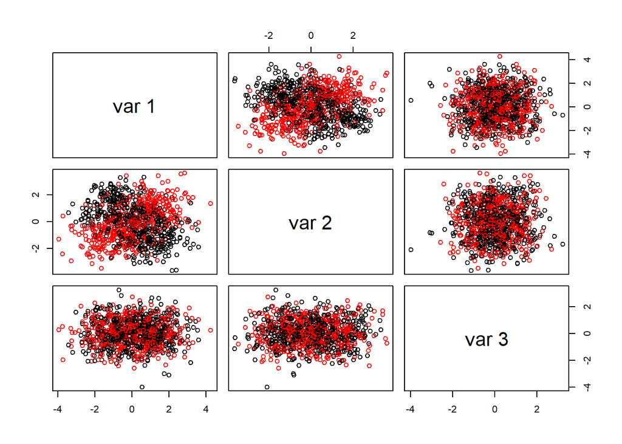

```r
# plot resulting attribute levels colored by outcome:
pairs(xyzTrain,col=as.numeric(classTrain))
```

We can see that it is the interaction between the first two variables that has influences the outcome (we simulated it this way, of course!) and that points belonging to each of the two classes cannot be readily separated by a single line in 2D (or a single surface in 3D).

```r
# Fit random forest to train data, obtain test error:
rfRes <- randomForest(xyzTrain,classTrain)
rfTmpTbl <- table(classTest,predict(rfRes,newdata=xyzTest))
rfTmpTbl
```

```
##
## classTest FALSE TRUE
##        -1  3574 1390
##        1   1663 3373
```

Random forest seems to do reasonably well on such dataset.

```r
# Fit LDA model to train data and evaluate error on the test data:
ldaRes <- lda(xyzTrain,classTrain)
ldaTmpTbl <- table(classTest,predict(ldaRes,newdata=xyzTest)$class)
ldaTmpTbl
```

```
##
## classTest FALSE TRUE
##        -1  3383 1581
##        1   3566 1470
```

LDA, on the other hand, not so good! (not a surprise given what we’ve seen above). What about a more flexible method such a KNN? Let’s check it out remembering that k – number of neighbors – in KNN is the parameter to modulate its flexibility (i.e. bias-variance tradeoff).

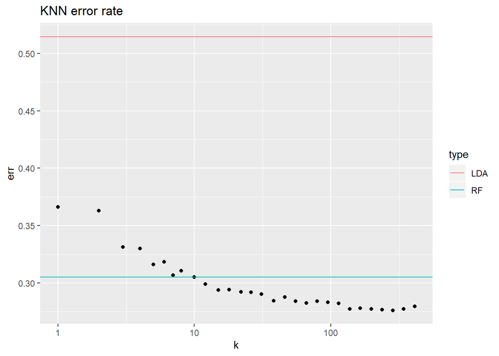

```r
# Fit KNN model at several levels of k:
dfTmp <- NULL
for ( kTmp in sort(unique(floor(1.2^(1:33)))) ) {
  knnRes <- knn(xyzTrain,xyzTest,classTrain,k=kTmp)
  tmpTbl <- table(classTest,knnRes)
  dfTmp <- rbind(dfTmp,data.frame(err=1-sum(diag(tmpTbl))/sum(tmpTbl),k=kTmp))
}
ggplot(dfTmp,aes(x=k,y=err))+geom_point()+scale_x_log10()+geom_hline(aes(yintercept = err,colour=type),data=data.frame(type=c("LDA","RF"),err=c(1-sum(diag(ldaTmpTbl))/sum(ldaTmpTbl),1-sum(diag(rfTmpTbl))/sum(rfTmpTbl))))+ggtitle("KNN error rate")
```

We can see from the above that there is a range of $k$ values where test error of KNN is the lowest and it is even lower that that of RF. Now would be a good moment to think why one would want to choose RF over KNN or vice a versa for modeling the data if the figure above was representative of their true relative performance on a new dataset.

For the purposes of this problem set you can use the code above (probably best to wrap reusable parts of it into function(s)) to generate data with varying numbers of predictors associated with outcome and not, different numbers of observations and differences in the average values of predictors’ between two classes as required below. These differences between datasets and parameters of the call to random forest will illustrate some of the factors influencing relative performance of random forest, LDA and KNN classifiers. When comparing to KNN performance, please choose value(s) of `k` such that it performs sufficiently well – feel free to refer to the plot above to select useful value(s) of `k` that you would like to evaluate here. Keep in mind also that the value of `k` cannot be larger than the number of observations in the training dataset.

# Sub-problem 1 (15 points): effect of sample size

Generate training datasets with `nObs=25`, `100` and `500` observations such that two variables are associated with the outcome as parameterized above and three are not associated and average difference between the two classes is the same as above (i.e. in the notation from the above code `nClassVars=2`, `nNoiseVars=3` and `deltaClass=1`). Obtain random forest, LDA and KNN test error rates on a (for greater stability of the results, much larger, say, with 10K observations) test dataset simulated from the same model. Describe the differences between different methods and across the sample sizes used here.

```r
#create data simulator function
data.generator <- function(nObs=1000, nClassVars=2, nNoiseVars=1, deltaClass=1){
  # How many observations:
  nObs <- nObs
  # How many predictors are associated with outcome:
  nClassVars <- nClassVars
  # How many predictors are not:
  nNoiseVars <- nNoiseVars
  # To modulate average difference between two classes' predictor values:
  deltaClass <- deltaClass
  # Simulate training and test datasets with an interaction
  # between attribute levels associated with the outcome:
  xyzTrain <- matrix(rnorm(nObs*(nClassVars+nNoiseVars)),
                     nrow=nObs,ncol=nClassVars+nNoiseVars)
  xyzTest <- matrix(rnorm(10*nObs*(nClassVars+nNoiseVars)),
                    nrow=10*nObs,ncol=nClassVars+nNoiseVars)
  classTrain <- 1
  classTest <- 1
  for ( iTmp in 1:nClassVars ) {
    deltaTrain <- sample(deltaClass*c(-1,1),nObs,replace=TRUE)
    xyzTrain[,iTmp] <- xyzTrain[,iTmp] + deltaTrain
    classTrain <- classTrain * deltaTrain
    deltaTest <- sample(deltaClass*c(-1,1),10*nObs,replace=TRUE)
    xyzTest[,iTmp] <- xyzTest[,iTmp] + deltaTest
    classTest <- classTest * deltaTest
  }
  classTrain <- factor(classTrain > 0)
  table(classTrain)
  # plot resulting attribute levels colored by outcome:
  pairs(xyzTrain,col=as.numeric(classTrain))
  # items to return:
  ret.list <- list("nObs" = nObs,
                   "nClassVars" = nClassVars,
                   "nNoiseVars" = nNoiseVars,
                   "deltaClass" = deltaClass,
                   "train" = xyzTrain,
                   "test" = xyzTest,
                   "classTrain" = classTrain,
                   "classTest" = classTest)
  return(ret.list)
}
```

```r
# simulate the data sets:
data25 <- data.generator(nObs = 25, nNoiseVars = 3)
```

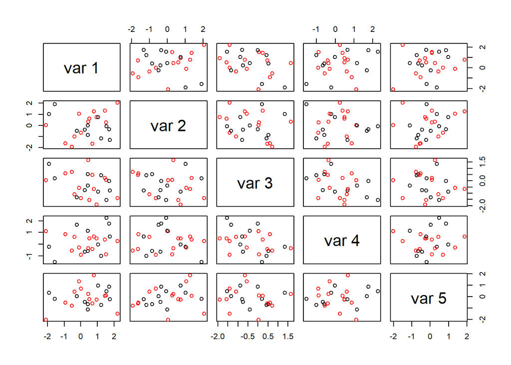

```r
data100 <- data.generator(nObs = 100, nNoiseVars = 3)
```

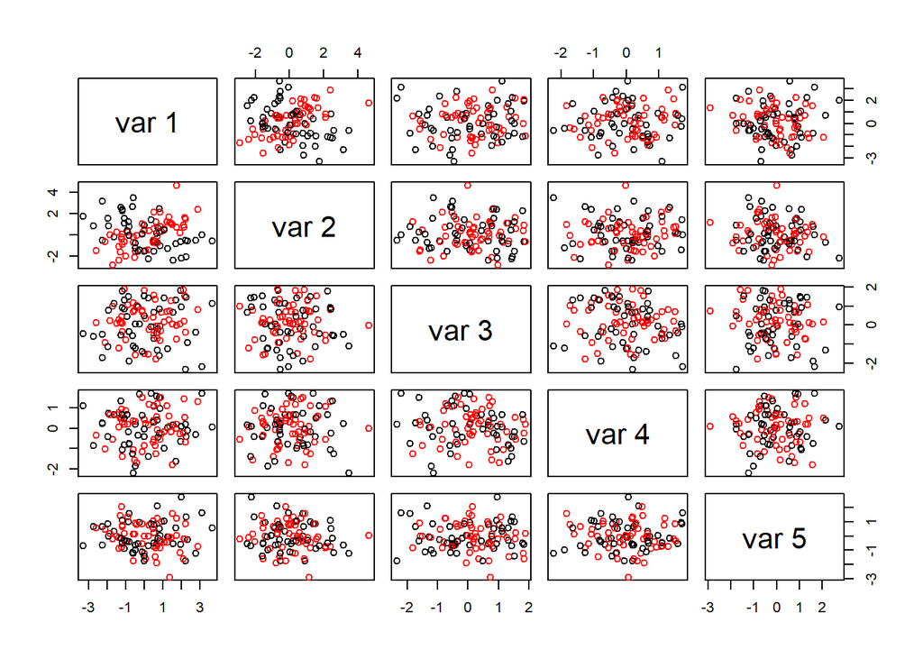

```r
data500 <- data.generator(nObs = 500, nNoiseVars = 3)
```

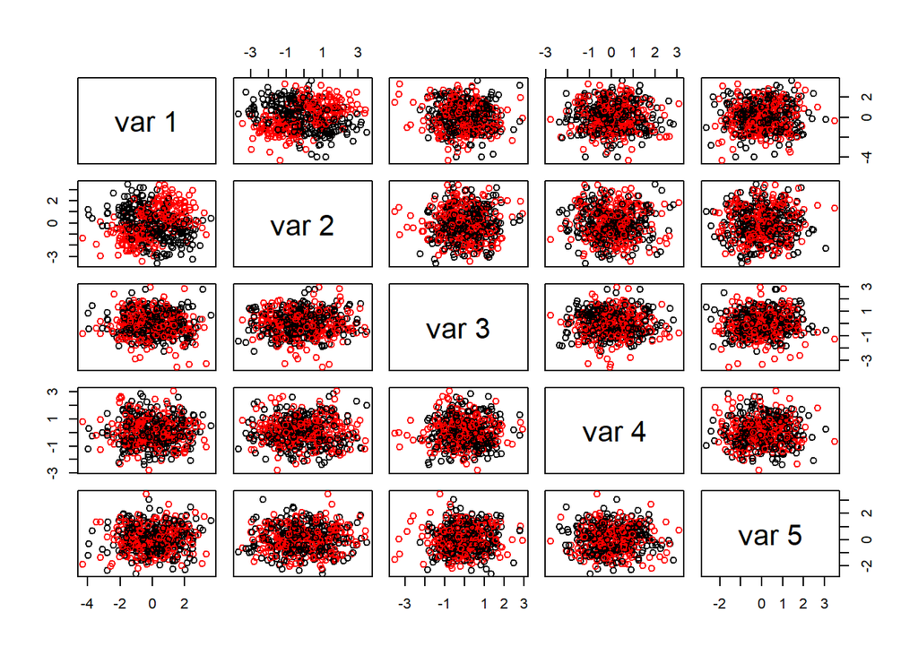

```r
# create the random forest function
# Fit random forest to train data, obtain test error:
rf.generator <- function( train.data, train.labels, test.data, test.labels,...){
  rfRes <- randomForest(train.data,train.labels, ...)
  rfTmpTbl <- table(test.labels,predict(rfRes,newdata=test.data))
  #list of items to return from the function:
  ret.list <- list("model" = rfRes, "prediction.table" = rfTmpTbl)
  return(ret.list)
}
```

```r
#generate random forests:
rf25 <- rf.generator( train.data = data25$train,
                      train.labels = data25$classTrain,
                      test.data = data25$test,
                      test.labels = data25$classTest)
rf100 <- rf.generator( train.data = data100$train,
                      train.labels = data100$classTrain,
                      test.data = data100$test,
                      test.labels = data100$classTest)
rf500 <- rf.generator( train.data = data500$train,
                      train.labels = data500$classTrain,
                      test.data = data500$test,
                      test.labels = data500$classTest)
```

```r
#create LDA function:
# Fit LDA model to train data and evaluate error on the test data:
lda.generator <- function( train.data,
                           train.labels,
                           test.data,
                           test.labels,
                           ...){
  ldaRes <- lda(train.data, train.labels,...)
  ldaTmpTbl <- table(test.labels, predict(ldaRes, newdata=test.data)$class)
  #list of items to return from the function:
  ret.list <- list("model" = ldaRes, "prediction.table" = ldaTmpTbl)
  return(ret.list)
}
```

```r
#generate LDA models
lda25 <- lda.generator( train.data = data25$train,
                      train.labels = data25$classTrain,
                      test.data = data25$test,
                      test.labels = data25$classTest)
lda100 <- lda.generator( train.data = data100$train,
                      train.labels = data100$classTrain,
                      test.data = data100$test,
                      test.labels = data100$classTest)
lda500 <- lda.generator( train.data = data500$train,
                      train.labels = data500$classTrain,
                      test.data = data500$test,
                      test.labels = data500$classTest)
```

```r
#create the KNN function:
# Fit KNN model at several levels of k:
knn.generator <- function( nObs,
                           train.data,
                           train.labels,
                           test.data,
                           test.labels,
                           ...){
  dfTmp <- NULL
  #set list of k values to try:
  kTmp <- sort(unique(floor(1.2^(1:55))))
  #initialize loop counter (also number of k's tries)
  loopcount <- 1
  #initialize k value for the first loop
  kloop <- kTmp[1]
  #create while loop to exhaust kTmp list but not exceed the observations:
  while ( kloop < if(nObs < 501){nObs+1} else {501} ) {
    knnRes <- knn(train.data,test.data,train.labels,k=kloop,...)
    tmpTbl <- table(test.labels,knnRes)
    dfTmp <- rbind(dfTmp,
                   data.frame(err=1-sum(diag(tmpTbl))/sum(tmpTbl),
                              k=kloop))
    #advance the loop counter (also the number of k's tries so far):
    loopcount <- loopcount + 1
    #select the next k value to try:
    kloop <- kTmp[(loopcount)]
  }
  #list of items to return from the function:
  ret.list = list("model" = knnRes, "prediction.table" = dfTmp)
  return(ret.list)
}

#create the error plot function, added data labels:
compare.plot <- function(dfTmp, lda.table, rf.table, title.add){
  p <- ggplot(dfTmp,aes(x=k,y=err,label=k))+
    scale_x_log10()+
    geom_hline(aes(yintercept = err,colour=type),
               data=data.frame(type=c("LDA","RF"),
                               err=c(1-sum(diag(lda.table))/sum(lda.table),
                                     1-sum(diag(rf.table))/sum(rf.table))))+
    ggtitle(paste0("KNN error rate, ",title.add))+
    geom_point() +
    geom_text(hjust = .01, nudge_x = 0.01)

  p
}
```

```r
#generate the KNN models
knn25 <- knn.generator( nObs = 25,
                        train.data = data25$train,
                      train.labels = data25$classTrain,
                      test.data = data25$test,
                      test.labels = data25$classTest)
knn100 <- knn.generator( nObs = 100,
                        train.data = data100$train,
                      train.labels = data100$classTrain,
                      test.data = data100$test,
                      test.labels = data100$classTest)
knn500 <- knn.generator( nObs = 500,
                        train.data = data500$train,
                      train.labels = data500$classTrain,
                      test.data = data500$test,
                      test.labels = data500$classTest)
```

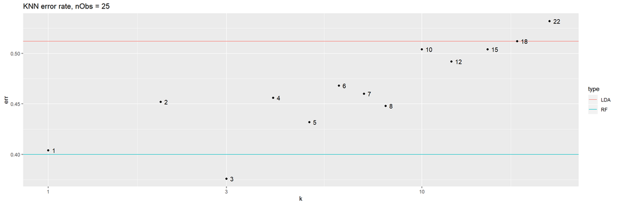

```r
# plot error comparison:
compare.plot(dfTmp = knn25$prediction.table,
             lda.table = lda25$prediction.table,
             rf.table = rf25$prediction.table,
             title.add = "nObs = 25")
```

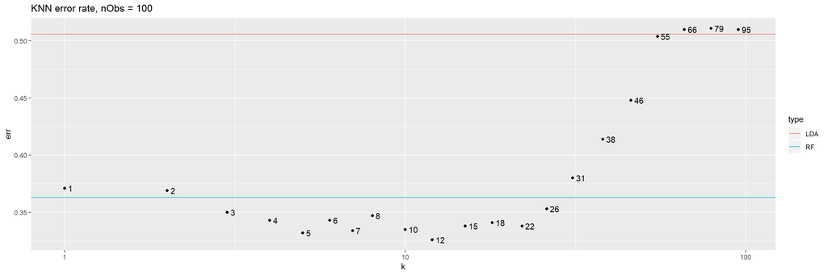

```r
compare.plot(dfTmp = knn100$prediction.table,
             lda.table = lda100$prediction.table,
             rf.table = rf100$prediction.table,
             title.add = "nObs = 100")
```

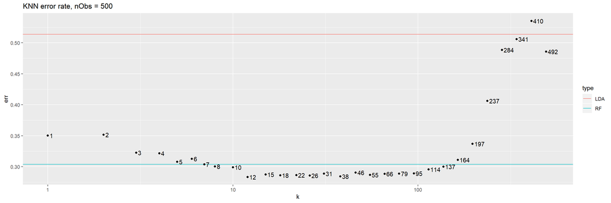

```r
compare.plot(dfTmp = knn500$prediction.table,
             lda.table = lda500$prediction.table,
             rf.table = rf500$prediction.table,
             title.add = "nObs = 500")
```

In most applications these error rates of above 0.3 would be considered to be poor.

# Sub-problem 2 (15 points): effect of signal magnitude

For training datasets with `nObs=100` and `500` observations simulate data as shown above with average differences between the two classes that are same as above, half of that and twice that (i.e. `deltaClass=0.5`, `1` and `2`). Obtain and plot test error rates of random forest, LDA and KNN for each of the six (two samples sizes times three signal magnitudes) combinations of sample size and signal strengths. As before use large test dataset (e.g. 10K observations or so) for greater stability of the results. Describe the most pronounced differences across error rates for those datasets: does the increase in the number of observations impact the error rate of the models? Does change in the magnitude of signal impact their performance? Are different classifier approaches impacted in a similar way?

```r
#generate data sets
data100.delta.5 <- data.generator(nObs = 100, nNoiseVars = 3, deltaClass = 0.5)
```

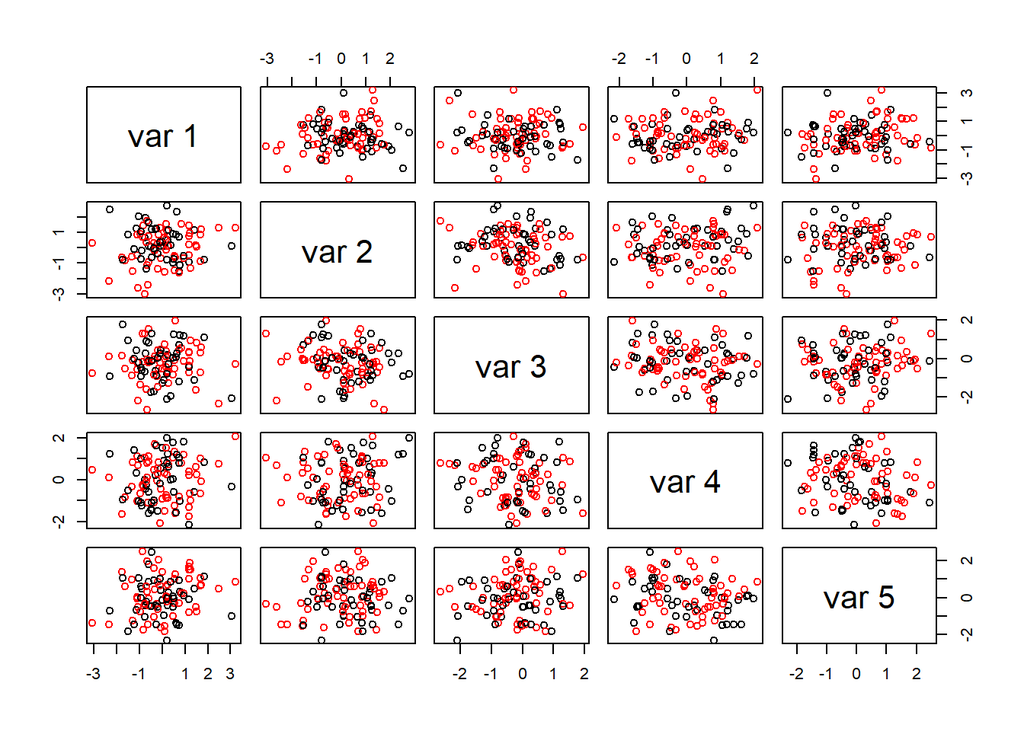

```r
data500.delta.5 <- data.generator(nObs = 500, nNoiseVars = 3, deltaClass = 0.5)
```

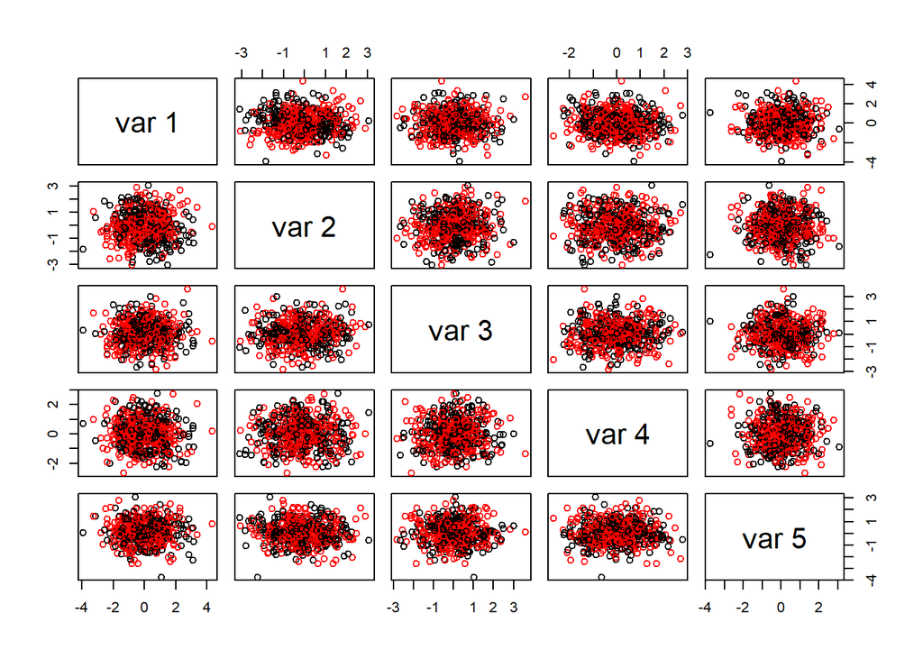

```r
data100.delta1 <- data.generator(nObs = 100, nNoiseVars = 3, deltaClass = 1)
```

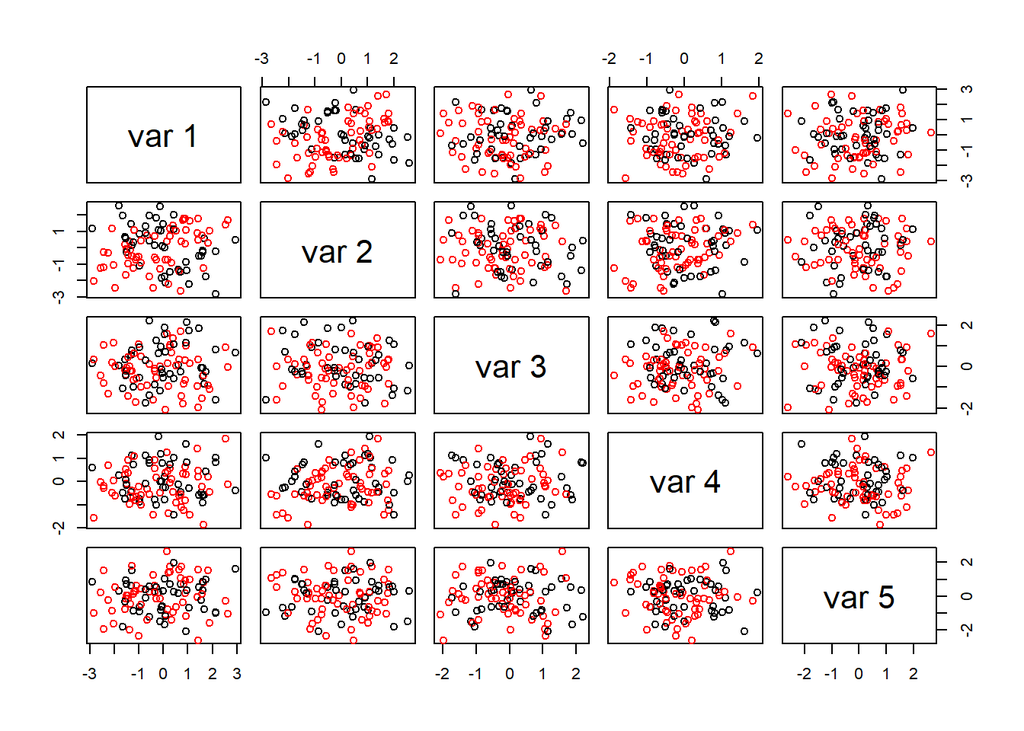

```r
data500.delta1 <- data.generator(nObs = 500, nNoiseVars = 3, deltaClass = 1)
```

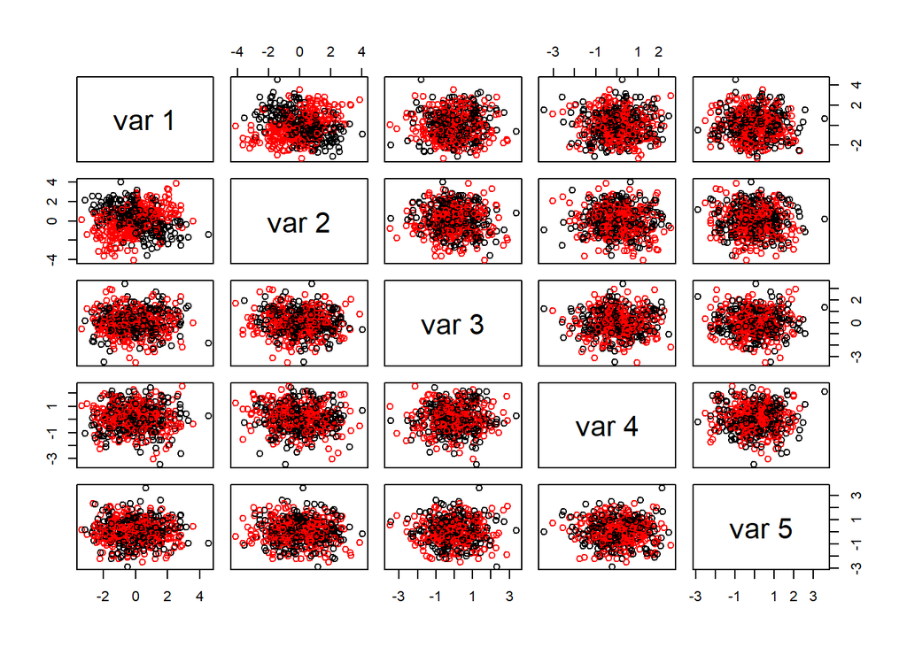

```r
data100.delta2 <- data.generator(nObs = 100, nNoiseVars = 3, deltaClass = 2)
```

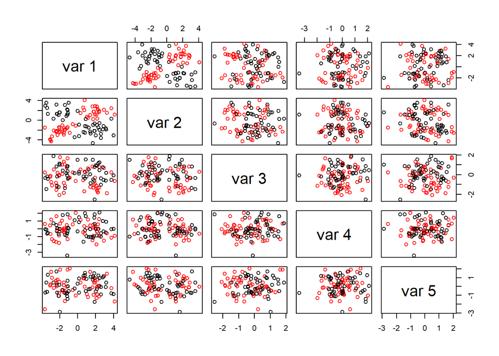

```r
data500.delta2 <- data.generator(nObs = 500, nNoiseVars = 3, deltaClass = 2)
```

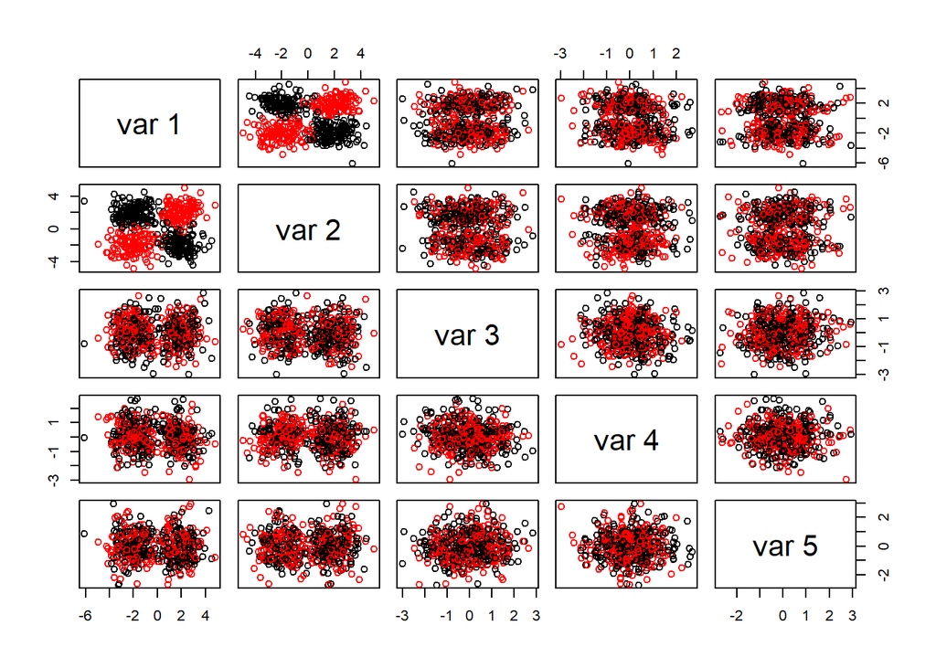

```r
#generate random forest models:
rf100.delta.5 <- rf.generator( train.data = data100.delta.5$train,
                      train.labels = data100.delta.5$classTrain,
                      test.data = data100.delta.5$test,
                      test.labels = data100.delta.5$classTest)
rf500.delta.5 <- rf.generator( train.data = data500.delta.5$train,
                      train.labels = data500.delta.5$classTrain,
                      test.data = data500.delta.5$test,
                      test.labels = data500.delta.5$classTest)
rf100.delta1 <- rf.generator( train.data = data100.delta1$train,
                      train.labels = data100.delta1$classTrain,
                      test.data = data100.delta1$test,
                      test.labels = data100.delta1$classTest)
rf500.delta1 <- rf.generator( train.data = data500.delta1$train,
                      train.labels = data500.delta1$classTrain,
                      test.data = data500.delta1$test,
                      test.labels = data500.delta1$classTest)
rf100.delta2 <- rf.generator( train.data = data100.delta2$train,
                      train.labels = data100.delta2$classTrain,
                      test.data = data100.delta2$test,
                      test.labels = data100.delta2$classTest)
rf500.delta2 <- rf.generator( train.data = data500.delta2$train,
                      train.labels = data500.delta2$classTrain,
                      test.data = data500.delta2$test,
                      test.labels = data500.delta2$classTest)
```

```r
#generate LDA models:
lda100.delta.5 <- lda.generator( train.data = data100.delta.5$train,
                      train.labels = data100.delta.5$classTrain,
                      test.data = data100.delta.5$test,
                      test.labels = data100.delta.5$classTest)
lda500.delta.5 <- lda.generator( train.data = data500.delta.5$train,
                      train.labels = data500.delta.5$classTrain,
                      test.data = data500.delta.5$test,
                      test.labels = data500.delta.5$classTest)
lda100.delta1 <- lda.generator( train.data = data100.delta1$train,
                      train.labels = data100.delta1$classTrain,
                      test.data = data100.delta1$test,
                      test.labels = data100.delta1$classTest)
lda500.delta1 <- lda.generator( train.data = data500.delta1$train,
                      train.labels = data500.delta1$classTrain,
                      test.data = data500.delta1$test,
                      test.labels = data500.delta1$classTest)
lda100.delta2 <- lda.generator( train.data = data100.delta2$train,
                      train.labels = data100.delta2$classTrain,
                      test.data = data100.delta2$test,
                      test.labels = data100.delta2$classTest)
lda500.delta2 <- lda.generator( train.data = data500.delta2$train,
                      train.labels = data500.delta2$classTrain,
                      test.data = data500.delta2$test,
                      test.labels = data500.delta2$classTest)
```

```r
#generate KNN models
knn100.delta.5 <- knn.generator( nObs = 100,
                                 train.data = data100.delta.5$train,
                      train.labels = data100.delta.5$classTrain,
                      test.data = data100.delta.5$test,
                      test.labels = data100.delta.5$classTest)
knn500.delta.5 <- knn.generator( nObs = 500,
                                 train.data = data500.delta.5$train,
                      train.labels = data500.delta.5$classTrain,
                      test.data = data500.delta.5$test,
                      test.labels = data500.delta.5$classTest)
knn100.delta1 <- knn.generator( nObs = 100,
                                train.data = data100.delta1$train,
                      train.labels = data100.delta1$classTrain,
                      test.data = data100.delta1$test,
                      test.labels = data100.delta1$classTest)
knn500.delta1 <- knn.generator( nObs = 500,
                                train.data = data500.delta1$train,
                      train.labels = data500.delta1$classTrain,
                      test.data = data500.delta1$test,
                      test.labels = data500.delta1$classTest)
knn100.delta2 <- knn.generator( nObs = 100,
                                train.data = data100.delta2$train,
                      train.labels = data100.delta2$classTrain,
                      test.data = data100.delta2$test,
                      test.labels = data100.delta2$classTest)
knn500.delta2 <- knn.generator( nObs = 500,
                                train.data = data500.delta2$train,
                      train.labels = data500.delta2$classTrain,
                      test.data = data500.delta2$test,
                      test.labels = data500.delta2$classTest)
```

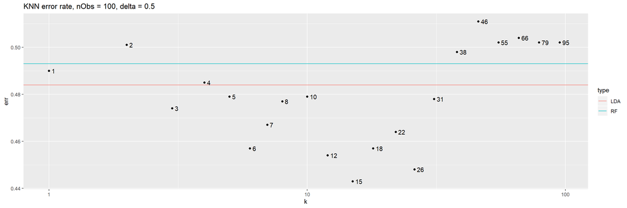

```r
#generate error plots with delta=0.5:
compare.plot(dfTmp = knn100.delta.5$prediction.table,
             lda.table = lda100.delta.5$prediction.table,
             rf.table = rf100.delta.5$prediction.table,
             title.add = "nObs = 100, delta = 0.5")
```

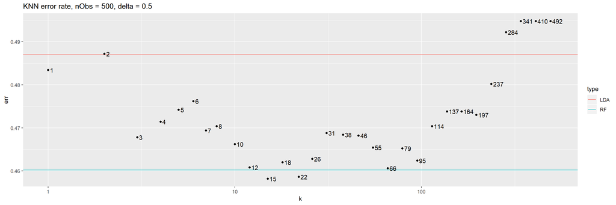

```r
compare.plot(dfTmp = knn500.delta.5$prediction.table,
             lda.table = lda500.delta.5$prediction.table,
             rf.table = rf500.delta.5$prediction.table,
             title.add = "nObs = 500, delta = 0.5")
```

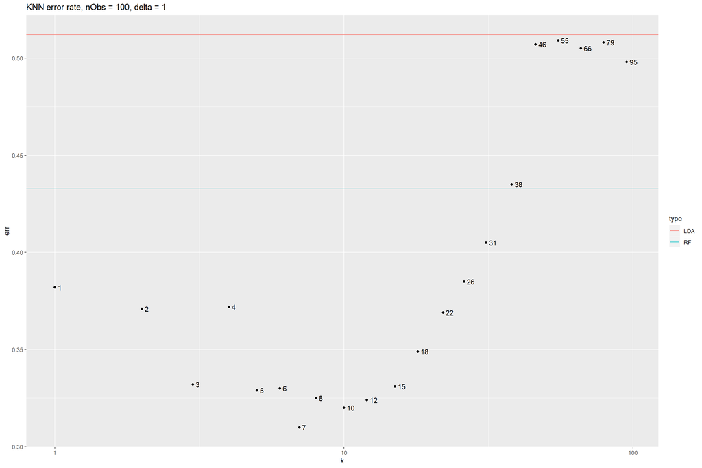

```r
#generate error plots with delta=1:
compare.plot(dfTmp = knn100.delta1$prediction.table,
             lda.table = lda100.delta1$prediction.table,
             rf.table = rf100.delta1$prediction.table,
             title.add = "nObs = 100, delta = 1")
```

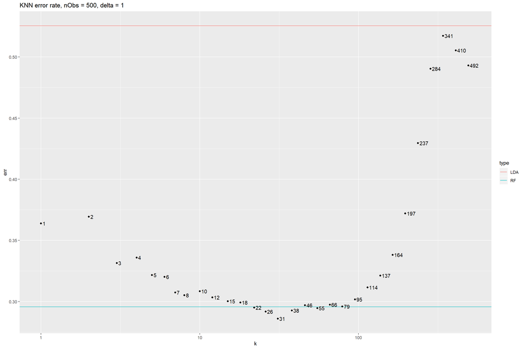

```r
compare.plot(dfTmp = knn500.delta1$prediction.table,
             lda.table = lda500.delta1$prediction.table,
             rf.table = rf500.delta1$prediction.table,
             title.add = "nObs = 500, delta = 1")
```

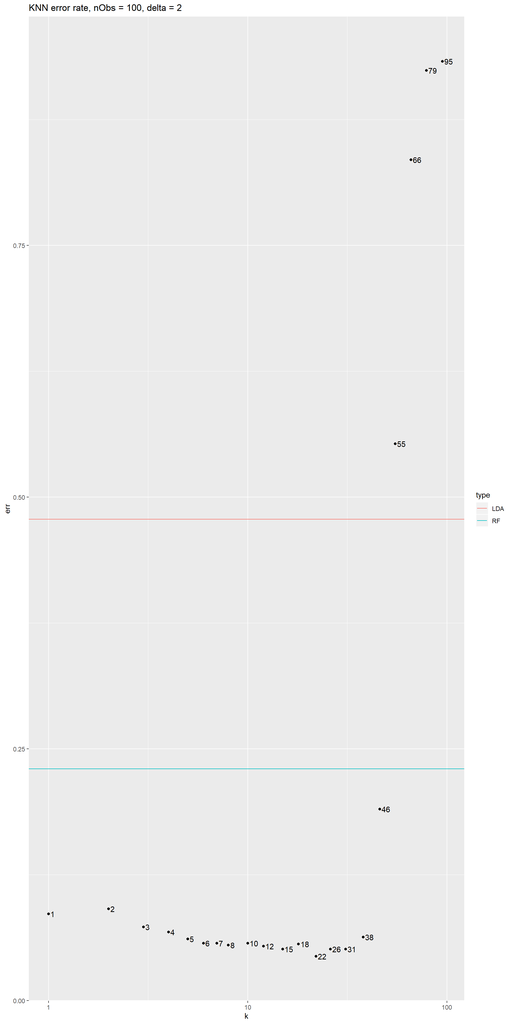

```r
#generate error plots with delta = 2:
compare.plot(dfTmp = knn100.delta2$prediction.table,
             lda.table = lda100.delta2$prediction.table,
             rf.table = rf100.delta2$prediction.table,
             title.add = "nObs = 100, delta = 2")
```

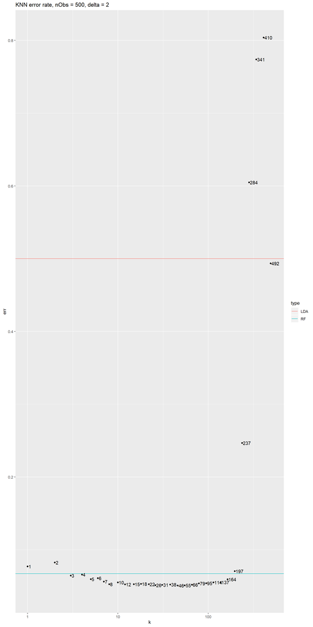

```r
compare.plot(dfTmp = knn500.delta2$prediction.table,
             lda.table = lda500.delta2$prediction.table,
             rf.table = rf500.delta2$prediction.table,
             title.add = "nObs = 500, delta = 2")
```

Random forest error rate improves slightly when going from n=100 to n=500 in all cases. At delta=0.5 it still only performs slightly better than 50%. It improves significantly as the delta value between the two variables increases with a minimum error around 0.05 at delta = 2 for nObs=500.

LDA error rate performs poorly (right around 50%) across all variants which incdicates that it is a poor model for nObs 100 and up. It does however outperform all other options for nObs=100 and delta=0.5 which indicates it may have some usefulness in select applications.

In summary, LDA performs best at low delta and low number of obervations but never better than 40% error rate. KNN, when optimized with the right value of k, performs the best across almost all other treatments. Random forest begins to show performance parity with KNN as nObs and delta increase. Neither random forest or KNN perform very well until delta is at least 2.

# Sub-problem 3 (15 points): varying counts of predictors

For all possible pairwise combinations of the numbers of variables associated with outcome (`nClassVars=2` and `5`) and those not associated with the outcome (`nNoiseVars=1`, `3` and `10`) – six pairwise combinations in total – obtain and present graphically test errors from random forest, LDA and KNN. Choose signal magnitude (`deltaClass`) and training data sample size so that this simulation yields non-trivial results – noticeable variability in the error rates across those six pairwise combinations of attribute counts. Describe the results: what is the impact of the increase of the number of attributes associated with the outcome on the classifier performance? What about the number of attributes not associated with outcome - does it affect classifier error rate? Are different classifier methods affected by these simulation parameters in a similar way?

```r
#set treatment levels for nClassVars and nNoiseVars
nClassVars = c(2,5)
nNoiseVars = c(1,3,10)

#create storage for loop data and initialize the iteration counter:
#space to store hyperparater settings for each loop:
settings = list()
#model results storage:
knns = list()
ldas = list()
rfs = list()
#storage counter initialization:
iterations = 1

for (i in nClassVars){
  for (j in nNoiseVars){
    #create one spot to change key hyperparameters:
    nObs = 500
    deltaClass = 2
    #store settings for this loop:
    settings[[iterations]] <- list("nObs" = nObs,
                                   "nNoiseVars" = j,
                                   "nClassVars" = i,
                                   "deltaClass" = deltaClass)
    #simulate data for the loop:
    data <- data.generator(nObs = nObs,
                           nNoiseVars = j,
                           nClassVars = i,
                           deltaClass = deltaClass)
    #generate random forest model and save its prediction results
    rfs[[iterations]] <- rf.generator( train.data = data$train,
                                  train.labels = data$classTrain,
                                  test.data = data$test,
                                  test.labels = data$classTest)$prediction.table
    #generate LDA model and save its prediction results
    ldas[[iterations]] <- lda.generator( train.data = data$train,
                                  train.labels = data$classTrain,
                                  test.data = data$test,
                                  test.labels = data$classTest)$prediction.table
    #generate KNN models and save its predictoin results
    knns[[iterations]] <- knn.generator( nObs = nObs,
                                  train.data = data$train,
                                  train.labels = data$classTrain,
                                  test.data = data$test,
                                  test.labels = data$classTest)$prediction.table
    #advance storage counter
    iterations = iterations + 1
  }
}
```

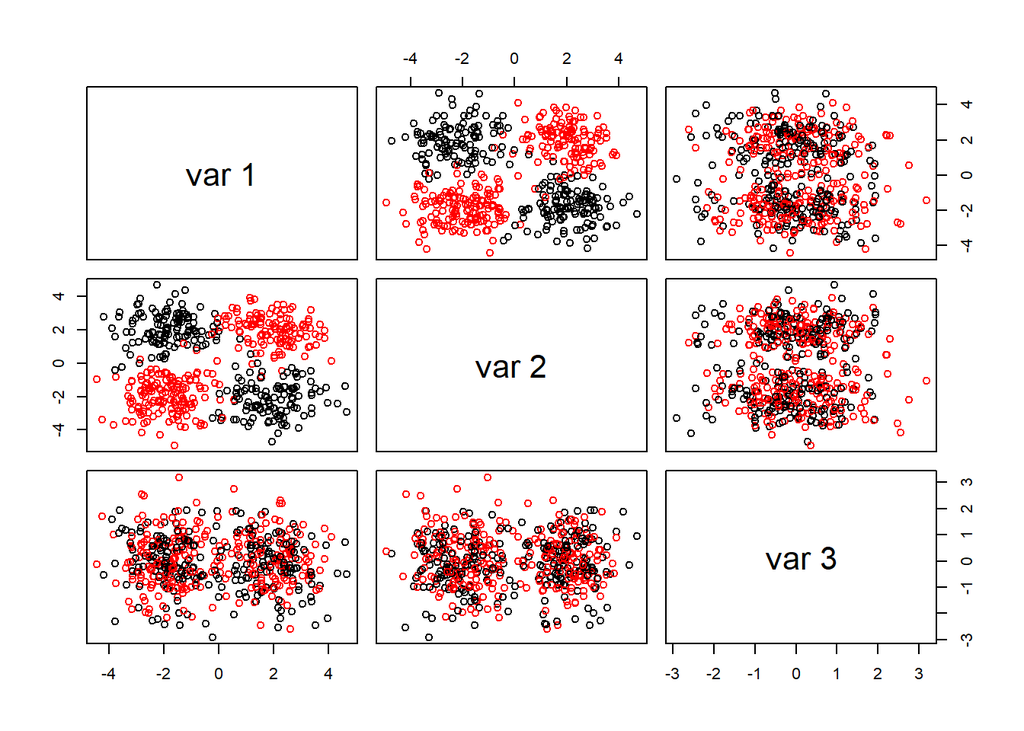

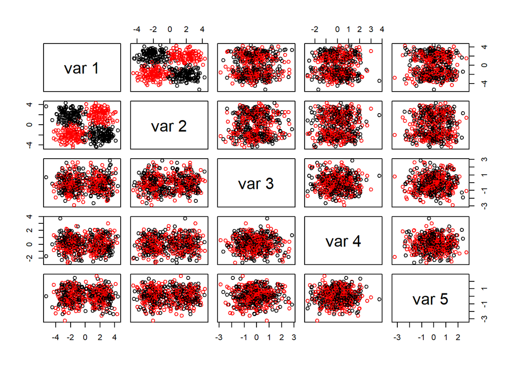

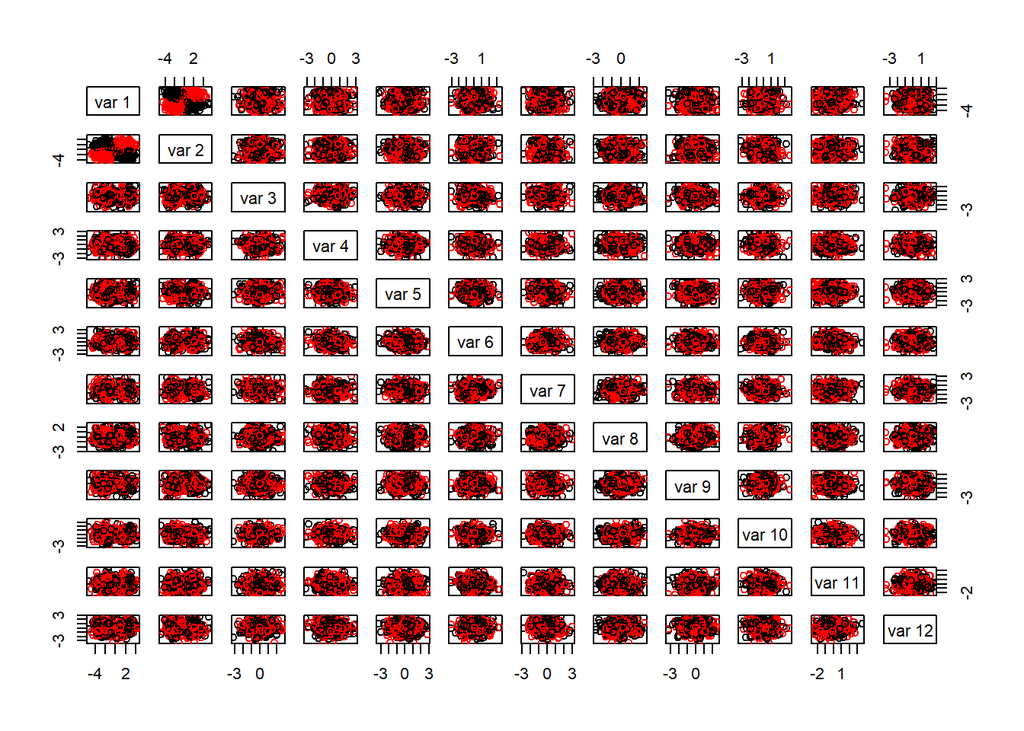

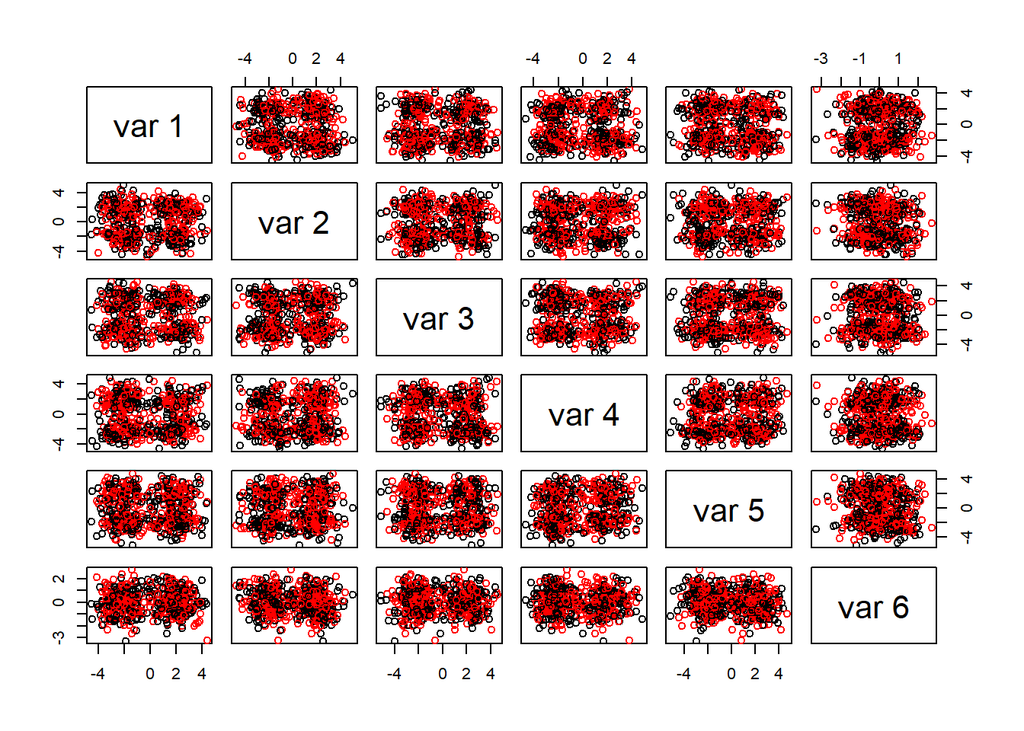

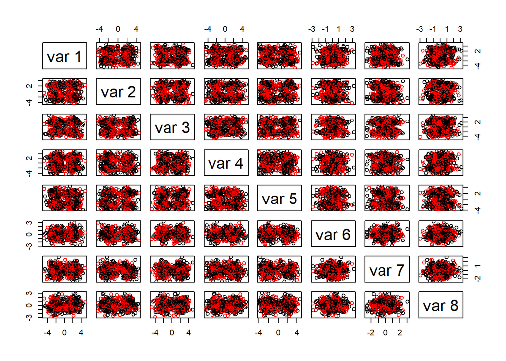

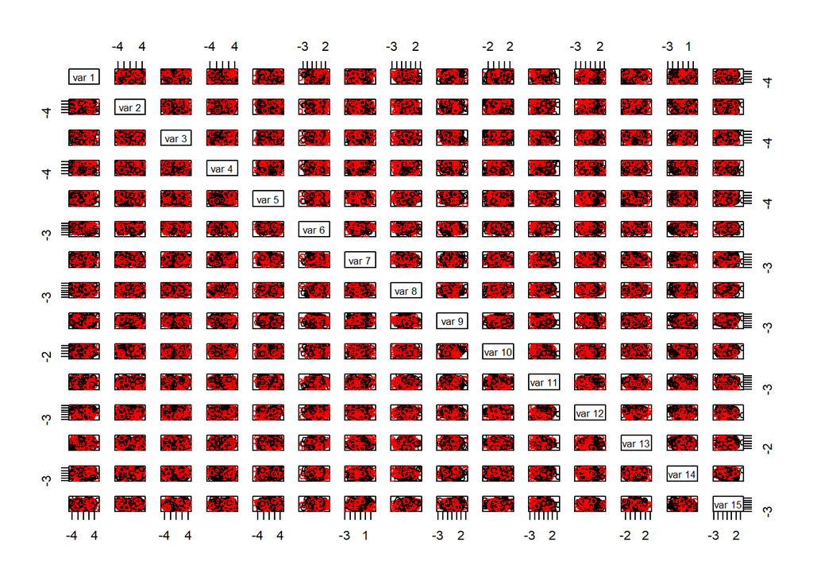

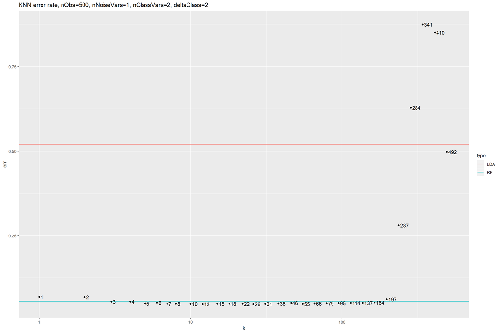

```r
#plot all error comparisons:
compare.plot(dfTmp = knns[[1]], lda.table = ldas[[1]], rf.table = rfs[[1]],
             title.add = paste0("nObs=",settings[[1]]$nObs,", nNoiseVars=",
                                settings[[1]]$nNoiseVars,", nClassVars=",
                                settings[[1]]$nClassVars,", deltaClass=",
                                settings[[1]]$deltaClass))
```

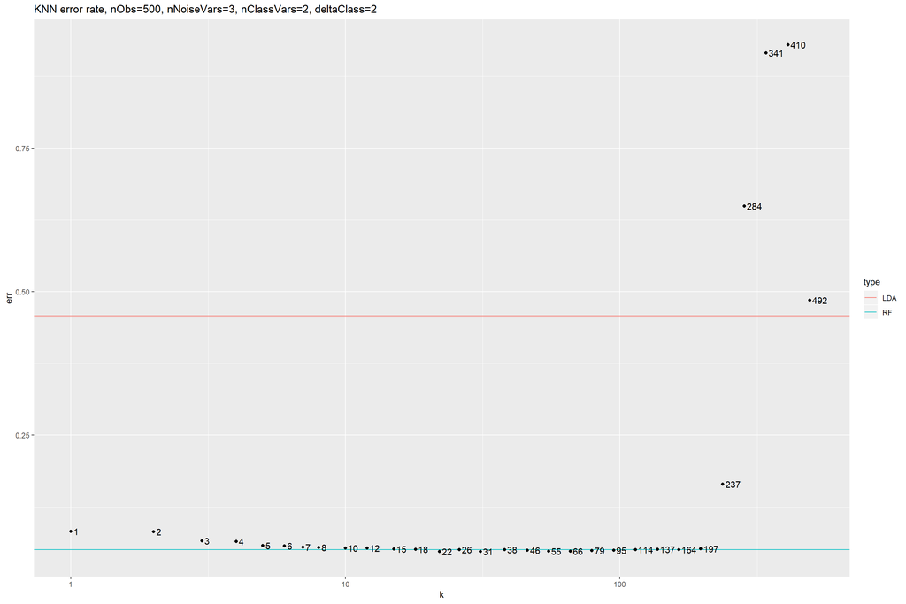

```r
compare.plot(dfTmp = knns[[2]], lda.table = ldas[[2]], rf.table = rfs[[2]],
             title.add = paste0("nObs=",settings[[2]]$nObs,", nNoiseVars=",
                                settings[[2]]$nNoiseVars,", nClassVars=",
                                settings[[2]]$nClassVars,", deltaClass=",
                                settings[[2]]$deltaClass))
```

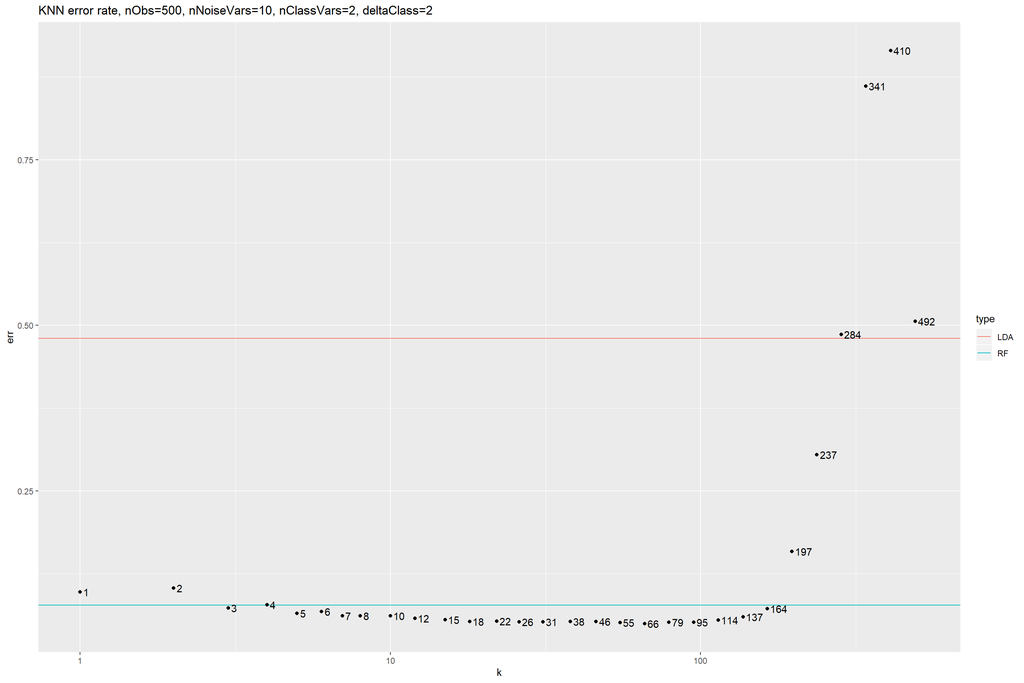

```r
compare.plot(dfTmp = knns[[3]], lda.table = ldas[[3]], rf.table = rfs[[3]],
             title.add = paste0("nObs=",settings[[3]]$nObs,", nNoiseVars=",
                                settings[[3]]$nNoiseVars,", nClassVars=",
                                settings[[3]]$nClassVars,", deltaClass=",
                                settings[[3]]$deltaClass))
```